### The C9orf72 expansion is associated with accelerated respiratory function decline in a large Amyotrophic Lateral Sclerosis cohort

#### Authors: James Rooney(1), Deirdre Murray(1,2), Anna Campion(2), Hannah Moloney(1), Rachel Tattersall(2), Mark Doherty(3), Michaela Hammond(1), Mark Heverin(1), Russell McLaughlin(3), Orla Hardiman(1,2).

#### Affiliations: 1. Academic Unit of Neurology, Trinity College Dublin. 2. Beaumont Hospital, Dublin, Ireland. 3. Smurfit Institute of Genetics, Trinity College Dublin, Dublin, Ireland.

https://www.tcd.ie/medicine/neurology/

This R Markdown file details the analysis for the paper of the same title. A full description of the background, methods, population, statistical analysis plan and results can by found therein.

```r
##### Descriptive Statistics
vars <- c("sex", "simp_site", "dx_delay", "age_on", "surv_t_months")
factorVars <- c("Diagnosis", "sex", "simp_site")
tab1 <- CreateTableOne(vars = vars, factorVars = factorVars, data=df.clin_72m,
                       strata = "C9", test = TRUE)
tab1.export <- print(tab1, quote = FALSE, noSpaces = TRUE,
                     printToggle = FALSE, showAllLevels = TRUE,
                     nonnormal = c("dx_delay","surv_t_months"))

print(tab1.export)
```

```
##                               Stratified by C9
##                                level    Normal
##   n                            ""       "572"
##   sex (%)                      "Female" "222 (38.8)"
##                                "Male"   "350 (61.2)"
##   simp_site (%)                "Spinal" "401 (70.1)"
##                                "Bulbar" "171 (29.9)"
##   dx_delay (median [IQR])      ""       "11.38 [6.91, 18.77]"
##   age_on (mean (SD))           ""       "62.00 (11.36)"
##   surv_t_months (median [IQR]) ""       "32.04 [21.37, 47.18]"
##                               Stratified by C9
##                                Expanded               p        test
##   n                            "58"                   ""       ""
##   sex (%)                      "29 (50.0)"            "0.129"  ""
##                                "29 (50.0)"            ""       ""
##   simp_site (%)                "37 (63.8)"            "0.398"  ""
##                                "21 (36.2)"            ""       ""
##   dx_delay (median [IQR])      "9.01 [6.07, 19.83]"   "0.297"  "nonnorm"
##   age_on (mean (SD))           "56.60 (9.08)"         "<0.001" ""
##   surv_t_months (median [IQR]) "29.82 [19.89, 50.44]" "0.564"  "nonnorm"
```

# Define a linear mixed model of SNIP vs C9 status

First, we will build a linear mixed model of SNIP by C9 status with and without spline terms on the time variable:

```r
mm_C9 <- lmer(SNIP.occ ~ onset2snip_mnths*C9 + (onset2snip_mnths  | ID),
                 data = df.snip_72m, REML = FALSE, control = lmerControl(optimizer ="Nelder_Mead"))
mm_C9_sp <- lmer(SNIP.occ ~ ns(onset2snip_mnths, 2) *C9 +
                     ( ns(onset2snip_mnths, 2)  | ID),
                 data = df.snip_72m, REML = FALSE, control = lmerControl(optimizer ="Nelder_Mead"))
anova(mm_C9, mm_C9_sp, test = "LRT")
```

```
## Data: df.snip_72m
## Models:
## mm_C9: SNIP.occ ~ onset2snip_mnths * C9 + (onset2snip_mnths | ID)
## mm_C9_sp: SNIP.occ ~ ns(onset2snip_mnths, 2) * C9 + (ns(onset2snip_mnths,
## mm_C9_sp:     2) | ID)
##          Df   AIC   BIC  logLik deviance  Chisq Chi Df Pr(>Chisq)
## mm_C9     8 19031 19076 -9507.5    19015
## mm_C9_sp 13 18821 18895 -9397.6    18795 219.81      5  < 2.2e-16 ***
## ---
## Signif. codes:  0 '***' 0.001 '**' 0.01 '*' 0.05 '.' 0.1 ' ' 1
```

The likelihood ratio test indicates that splines improve the fit. Summary of spline model:

```r
summary(mm_C9_sp)
```

```
## Linear mixed model fit by maximum likelihood  ['lmerMod']
## Formula: SNIP.occ ~ ns(onset2snip_mnths, 2) * C9 + (ns(onset2snip_mnths,
##     2) | ID)
##    Data: df.snip_72m
## Control: lmerControl(optimizer = "Nelder_Mead")
##
##      AIC      BIC   logLik deviance df.resid
##  18821.2  18895.0  -9397.6  18795.2     2152
##
## Scaled residuals:
##     Min      1Q  Median      3Q     Max
## -4.8139 -0.3769 -0.0334  0.3755  5.1064
##
## Random effects:
##  Groups   Name                     Variance Std.Dev. Corr
##  ID       (Intercept)               1626.4   40.33
##           ns(onset2snip_mnths, 2)1 12438.5  111.53   -0.85
##           ns(onset2snip_mnths, 2)2 11586.9  107.64   -0.34  0.39
##  Residual                            101.9   10.10
## Number of obs: 2165, groups:  ID, 630
##
## Fixed effects:
##                                     Estimate Std. Error t value
## (Intercept)                           72.187      2.776  26.008
## ns(onset2snip_mnths, 2)1             -53.423      6.872  -7.774
## ns(onset2snip_mnths, 2)2             -19.327      8.515  -2.270
## C9Expanded                            -7.021      8.889  -0.790
## ns(onset2snip_mnths, 2)1:C9Expanded  -18.351     22.494  -0.816
## ns(onset2snip_mnths, 2)2:C9Expanded  -38.052     30.498  -1.248
##
## Correlation of Fixed Effects:
##             (Intr) ns(2_,2)1 ns(2_,2)2 C9Expn n(2_,2)1:
## ns(ns2_,2)1 -0.798
## ns(ns2_,2)2  0.152  0.275
## C9Expanded  -0.312  0.249    -0.047
## n(2_,2)1:C9  0.244 -0.305    -0.084    -0.771
## n(2_,2)2:C9 -0.042 -0.077    -0.279     0.165  0.303
```

Since we know a priori that there is differential follow up of the longitudinal variables by C9 status owing to the poorer prognosis associated with carriage of the C9orf72 expansion, we will construct a joint longitudinal and time to event model which can account for such differential loss to follow-up. Therefore we must first define a Cox model. We will include known ALS prognostic variables in Cox model: age of onset, diagnostic delay, site of onset and C9 status. A delayed entry model will be specified using diagnostic delay as time of entry.

### Define a Cox survival model

Summary of Cox model:

```r
summary(coxC9)
```

```
## Call:
## coxph(formula = Surv(time = dx_delay, time2 = surv_t2_months,
##     fail) ~ age_on + dx_delay2 + simp_site + C9, data = df.clin_72m,
##     model = TRUE, x = TRUE)
##
##   n= 630, number of events= 490
##
##                      coef exp(coef)  se(coef)      z Pr(>|z|)
## age_on           0.023069  1.023338  0.004409  5.232 1.67e-07 ***
## dx_delay2       -0.031370  0.969117  0.005978 -5.248 1.54e-07 ***
## simp_siteBulbar  0.244099  1.276471  0.098393  2.481 0.013107 *
## C9Expanded       0.481130  1.617902  0.146167  3.292 0.000996 ***
## ---
## Signif. codes:  0 '***' 0.001 '**' 0.01 '*' 0.05 '.' 0.1 ' ' 1
##
##                 exp(coef) exp(-coef) lower .95 upper .95
## age_on             1.0233     0.9772    1.0145    1.0322
## dx_delay2          0.9691     1.0319    0.9578    0.9805
## simp_siteBulbar    1.2765     0.7834    1.0526    1.5480
## C9Expanded         1.6179     0.6181    1.2149    2.1546
##
## Concordance= 0.645  (se = 0.013 )
## Rsquare= 0.106   (max possible= 1 )
## Likelihood ratio test= 70.48  on 4 df,   p=2e-14
## Wald test            = 65.87  on 4 df,   p=2e-13
## Score (logrank) test = 66.82  on 4 df,   p=1e-13
```

Cox model results are compatible with previous literature for Irish ALS cohorts.

### Define a joint longtiudinal and time to event model

Summary of the joint model:

```r
summary(JMFit_C9)
```

```
##
## Call:
## jointModelBayes(lmeObject = lmeC9, survObject = coxC9, timeVar = "onset2snip_mnths",
##     verbose = FALSE)
##
## Data Descriptives:
## Longitudinal Process     Event Process
## Number of Observations: 2165 Number of Events: 490 (77.8%)
## Number of subjects: 630
##
## Joint Model Summary:
## Longitudinal Process: Linear mixed-effects model
## Event Process: Relative risk model with penalized-spline-approximated
##      baseline risk function
## Parameterization: Time-dependent value
##
##       LPML      DIC       pD
##  -21535.79 42645.88 1858.213
##
## Variance Components:
##                             StdDev    Corr
## (Intercept)                41.7722  (Intr)  n(2_,2
## ns(onset2snip_mnths, 2)1  112.2345 -0.8622
## ns(onset2snip_mnths, 2)2   91.3013 -0.3297  0.2766
## Residual                   10.3289
##
## Coefficients:
## Longitudinal Process
##                                        Value Std.Err Std.Dev     2.5%
## (Intercept)                          70.0317  0.1143  1.9808  65.9551
## ns(onset2snip_mnths, 2)1            -50.3896  0.3981  5.0965 -60.4309
## ns(onset2snip_mnths, 2)2            -21.0696  0.2715  4.3010 -29.3831
## C9Expanded                           -8.5193  0.1482  4.0932 -16.4161
## ns(onset2snip_mnths, 2)1:C9Expanded -11.6137  0.3043  8.4281 -28.0675
## ns(onset2snip_mnths, 2)2:C9Expanded -16.2001  0.3042  8.6916 -33.4366
##                                        97.5%      P
## (Intercept)                          73.9544 <0.001
## ns(onset2snip_mnths, 2)1            -40.3416 <0.001
## ns(onset2snip_mnths, 2)2            -12.8442 <0.001
## C9Expanded                           -0.2477  0.042
## ns(onset2snip_mnths, 2)1:C9Expanded   4.9719  0.164
## ns(onset2snip_mnths, 2)2:C9Expanded   0.1157  0.056
##
## Event Process
##                    Value Std.Err  Std.Dev    2.5%    97.5%      P
## age_on            0.0147  0.0010   0.0053  0.0051   0.0249  0.006
## dx_delay2        -0.0291  0.0019   0.0082 -0.0446  -0.0128 <0.001
## simp_siteBulbar  -0.1305  0.0258   0.1198 -0.3542   0.1398  0.245
## C9Expanded       -0.0480  0.0525   0.2069 -0.4429   0.3222  0.795
## Assoct           -0.0389  0.0006   0.0038 -0.0467  -0.0314 <0.001
## tauBs           177.1512 35.9217 119.8260 35.7207 472.5217     NA
##
## MCMC summary:
## iterations: 20000
## adapt: 3000
## burn-in: 3000
## thinning: 10
## time: 2.9 min
```

Summary of the JM event process on exponential scale (i.e. to get Hazard Ratios)

```r
format(exp(summary(JMFit_C9)$`CoefTable-Event`), digits = 3)
```

```
##                 Value       Std.Err     Std.Dev     2.5%
## age_on          " 1.01e+00" " 1.00e+00" " 1.01e+00" " 1.01e+00"
## dx_delay2       " 9.71e-01" " 1.00e+00" " 1.01e+00" " 9.56e-01"
## simp_siteBulbar " 8.78e-01" " 1.03e+00" " 1.13e+00" " 7.02e-01"
## C9Expanded      " 9.53e-01" " 1.05e+00" " 1.23e+00" " 6.42e-01"
## Assoct          " 9.62e-01" " 1.00e+00" " 1.00e+00" " 9.54e-01"
## tauBs           " 8.63e+76" " 3.99e+15" " 1.10e+52" " 3.26e+15"
##                 97.5%       P
## age_on          " 1.03e+00" " 1.01e+00"
## dx_delay2       " 9.87e-01" " 1.00e+00"
## simp_siteBulbar " 1.15e+00" " 1.28e+00"
## C9Expanded      " 1.38e+00" " 2.21e+00"
## Assoct          " 9.69e-01" " 1.00e+00"
## tauBs           "1.64e+205" "       NA"
```

The Event process results indicate that the longitudinal value (Assoct) is associated with survival in the JM. Dx delay and age remain important while bulbar onset and C9 expansion lose importance.

Next we generate a plot of predicted SNIP values from joint model fit:

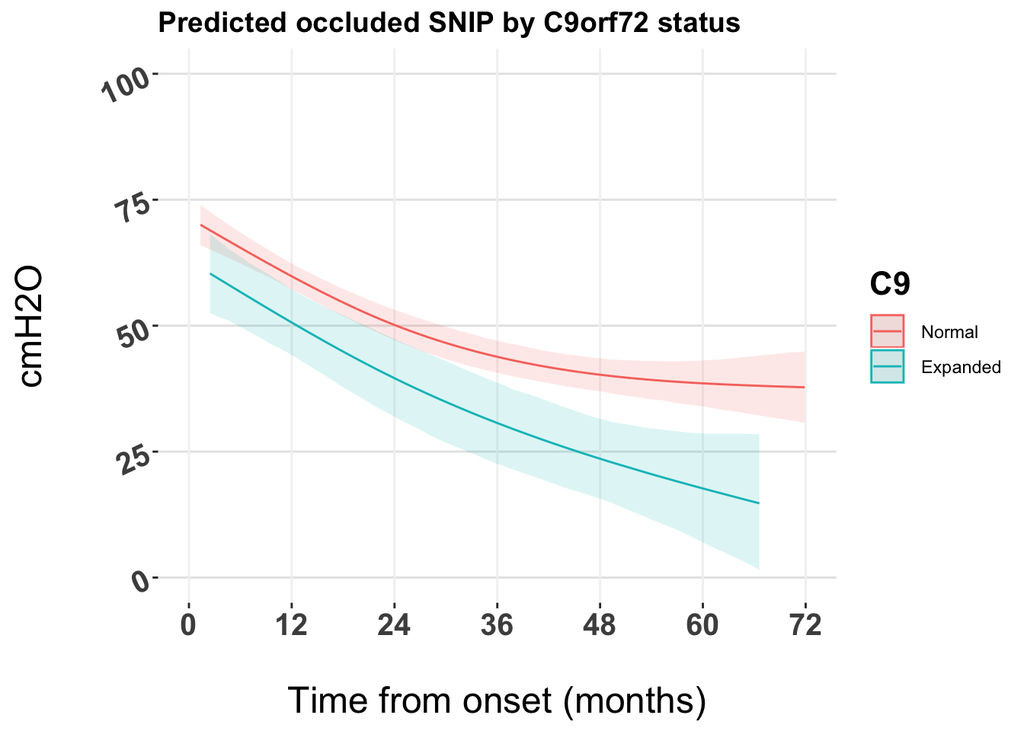

Predicted outcomes from the JM indicate that C9 patients have lower SNIP values across the follow-up time. Both normal and C9 expanded cases exhibit non-linear although this is more apparent in the normal cases.

How does the ALSFRS respiratory score characterise C9 modelled versus the same explatory variables in the joint model? -> note that not all patients have ALSFRS data therefore the Cox model also needs to be re-specified.

```r
length(unique(df.snip_72m$ID))
```

```
## [1] 630
```

```r
length(unique(df.alsfrs_72m$ID))
```

```
## [1] 450
```

Summary of ALSFRS JM:

```r
summary(JMFit_ALSFRS)
```

```
##
## Call:
## jointModelBayes(lmeObject = lmeALSFRS, survObject = coxALSFRS,
##     timeVar = "alsfrs_dly_mnths", verbose = FALSE)
##
## Data Descriptives:
## Longitudinal Process     Event Process
## Number of Observations: 1728 Number of Events: 346 (76.9%)
## Number of subjects: 450
##
## Joint Model Summary:
## Longitudinal Process: Linear mixed-effects model
## Event Process: Relative risk model with penalized-spline-approximated
##      baseline risk function
## Parameterization: Time-dependent value
##
##       LPML      DIC       pD
##  -8874.896 17387.94 1301.425
##
## Variance Components:
##                            StdDev    Corr
## (Intercept)                2.9995  (Intr)  n(__,2
## ns(alsfrs_dly_mnths, 2)1  10.7824 -0.9395
## ns(alsfrs_dly_mnths, 2)2  10.2441 -0.0618  0.1872
## Residual                   1.0991
##
## Coefficients:
## Longitudinal Process
##                                       Value Std.Err Std.Dev    2.5%
## (Intercept)                         11.7214  0.0107  0.1856 11.3543
## ns(alsfrs_dly_mnths, 2)1            -6.0373  0.0381  0.6589 -7.2867
## ns(alsfrs_dly_mnths, 2)2            -5.1687  0.0322  0.6182 -6.3774
## C9Expanded                           0.7251  0.0285  0.5495 -0.2980
## ns(alsfrs_dly_mnths, 2)1:C9Expanded -2.8408  0.1067  1.9588 -6.7733
## ns(alsfrs_dly_mnths, 2)2:C9Expanded -3.2294  0.1068  1.9098 -6.9884
##                                       97.5%      P
## (Intercept)                         12.0724 <0.001
## ns(alsfrs_dly_mnths, 2)1            -4.7098 <0.001
## ns(alsfrs_dly_mnths, 2)2            -3.9377 <0.001
## C9Expanded                           1.8267  0.184
## ns(alsfrs_dly_mnths, 2)1:C9Expanded  0.8486  0.140
## ns(alsfrs_dly_mnths, 2)2:C9Expanded  0.5091  0.098
##
## Event Process
##                    Value Std.Err  Std.Dev     2.5%    97.5%      P
## age_on            0.0290  0.0006   0.0048   0.0207   0.0392 <0.001
## dx_delay2        -0.0323  0.0010   0.0062  -0.0471  -0.0215 <0.001
## simp_siteBulbar   0.2200  0.0194   0.1062   0.0296   0.4528  0.018
## C9Expanded        0.2504  0.0345   0.1781  -0.0781   0.6267  0.172
## Assoct           -0.1491  0.0027   0.0194  -0.1896  -0.1148 <0.001
## tauBs           403.1814 31.7239 210.7283 106.3690 884.9282     NA
##
## MCMC summary:
## iterations: 20000
## adapt: 3000
## burn-in: 3000
## thinning: 10
## time: 2.1 min
```

Next we generate a plot of predicted ALSFRS values from joint model fit:

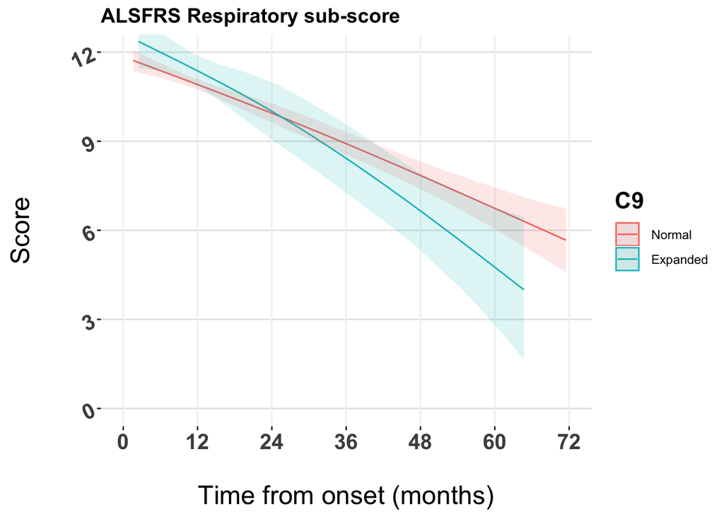

The ALSFRS respiratory subscores predicted from the linear mixed models show less distinction between C9 normal and C9 expanded cases. Indeed, they are indistinguishable for the first 2.5 - 3 years before the C9 expanded curve tends to decrease more quickly. This stands in contrast to the occluded SNIP graphs, which are distinct throughout the follow-up time.

## Exploration of trend over time of C9 x gender x site of onset subgroups

To further explore the characteristics of occluded SNIP values in C9 patients over time, the joint model will be expanded to include longitudinal interactions of C9 with sex and site to investigate the hypothesis that the C9 expansion might affect respiratory function differently by sex and site of onset subgroups. We have seen previously that the prognostic impact of the C9 expansion is more prominent in male spinal onset cases.

Does the inclusion of sex and site improve the model fit? Can test this using anova of the respective JM’s:

```
##                   df      LPML      DIC       pD
## JMFit_C9        1929 -21535.79 42645.88 1858.213
## JMFit_C9sexsite 1947 -21519.87 42485.05 1835.888
```

The inclusion of sex and site improves model fit by various measures.

Summary of the joint model:

```r
summary(JMFit_C9sexsite)
```

```
##
## Call:
## jointModelBayes(lmeObject = lmeC9_sex_site, survObject = coxC9,
##     timeVar = "onset2snip_mnths", verbose = FALSE)
##
## Data Descriptives:
## Longitudinal Process     Event Process
## Number of Observations: 2165 Number of Events: 490 (77.8%)
## Number of subjects: 630
##
## Joint Model Summary:
## Longitudinal Process: Linear mixed-effects model
## Event Process: Relative risk model with penalized-spline-approximated
##      baseline risk function
## Parameterization: Time-dependent value
##
##       LPML      DIC       pD
##  -21519.87 42485.05 1835.888
##
## Variance Components:
##                             StdDev    Corr
## (Intercept)                40.9330  (Intr)  n(2_,2
## ns(onset2snip_mnths, 2)1  109.4677 -0.8611
## ns(onset2snip_mnths, 2)2   84.6399 -0.3096  0.2993
## Residual                   10.3244
##
## Coefficients:
## Longitudinal Process
##                                                           Value Std.Err
## (Intercept)                                             59.9647  0.1416
## ns(onset2snip_mnths, 2)1                               -34.6378  0.2527
## ns(onset2snip_mnths, 2)2                               -19.9495  0.2458
## C9Expanded                                              -5.7786  0.1878
## sexMale                                                 17.9925  0.1935
## siteBulbar                                               1.6839  0.1606
## ns(onset2snip_mnths, 2)1:C9Expanded                     -5.0799  0.3362
## ns(onset2snip_mnths, 2)2:C9Expanded                    -17.7136  0.3379
## ns(onset2snip_mnths, 2)1:sexMale                       -19.2911  0.3239
## ns(onset2snip_mnths, 2)2:sexMale                       -23.9555  0.2273
## C9Expanded:sexMale                                     -12.4395  0.2819
```

[output cut: 64 more lines]

```
## Event Process
##                    Value Std.Err Std.Dev    2.5%    97.5%      P
## age_on            0.0157  0.0007  0.0049  0.0069   0.0255 <0.001
## dx_delay2        -0.0309  0.0012  0.0068 -0.0450  -0.0180 <0.001
## simp_siteBulbar  -0.2462  0.0238  0.1199 -0.4710  -0.0184  0.027
## C9Expanded        0.0126  0.0363  0.1796 -0.3084   0.3522  0.997
## Assoct           -0.0381  0.0004  0.0034 -0.0453  -0.0317 <0.001
## tauBs           141.8851 12.0800 78.1577 43.8752 341.0782     NA
##
## MCMC summary:
## iterations: 20000
## adapt: 3000
## burn-in: 3000
## thinning: 10
## time: 4 min
```

Summary of the JM event process on exponential scale (i.e. to get Hazard Ratios)

```r
format(exp(summary(JMFit_C9sexsite)$`CoefTable-Event`), digits = 3)
```

```
##                 Value       Std.Err     Std.Dev     2.5%
## age_on          " 1.02e+00" " 1.00e+00" " 1.00e+00" " 1.01e+00"
## dx_delay2       " 9.70e-01" " 1.00e+00" " 1.01e+00" " 9.56e-01"
## simp_siteBulbar " 7.82e-01" " 1.02e+00" " 1.13e+00" " 6.24e-01"
## C9Expanded      " 1.01e+00" " 1.04e+00" " 1.20e+00" " 7.35e-01"
## Assoct          " 9.63e-01" " 1.00e+00" " 1.00e+00" " 9.56e-01"
## tauBs           " 4.17e+61" " 1.76e+05" " 8.78e+33" " 1.13e+19"
##                 97.5%       P
## age_on          " 1.03e+00" " 1.00e+00"
## dx_delay2       " 9.82e-01" " 1.00e+00"
## simp_siteBulbar " 9.82e-01" " 1.03e+00"
## C9Expanded      " 1.42e+00" " 2.71e+00"
## Assoct          " 9.69e-01" " 1.00e+00"
## tauBs           "1.34e+148" "       NA"
```

Generate a plot of JM_C9sexsite model fit:

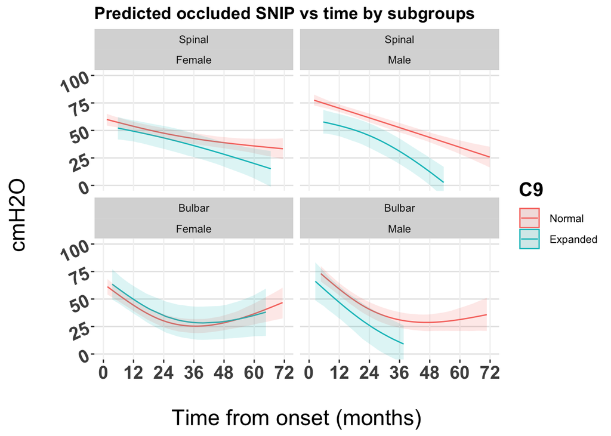

For male spinal onset patients there is a clear difference between C9 normal and C9 expanded groups. There is a difference also for male bulbar onset patients although confidence intervals overlap. For female spinal and bulbar onset patients there is little difference in longitudinal SNIP characteristics between C9 normal and C9 expanded patients.